# apple_stock_ml

```python
import pandas as pd
import numpy as np
import matplotlib.pyplot as plt
import seaborn as sb
from scipy.stats import pearsonr
from sklearn.model_selection import train_test_split
from sklearn.metrics import mean_squared_error, mean_absolute_error
from sklearn.metrics import r2_score, accuracy_score
from sklearn.metrics import confusion_matrix, ConfusionMatrixDisplay
from sklearn.inspection import permutation_importance
from sklearn.ensemble import RandomForestRegressor
import xgboost as xgb

df = pd.read_csv("apple_stock_enriched_phase2_output.csv")
df.head()
```

|  | Title | Date | Link | Source | Open | High | Low | Close | Volume | Dividends | ... | ATR | ADX | gpt_summary | gpt_sentiment_direction | gpt_sentiment_score | gpt_positive_score | gpt_negative_score | gpt_event_type | gpt_relevance_to_apple | gpt_importance_score |
| --- | --- | --- | --- | --- | --- | --- | --- | --- | --- | --- | --- | --- | --- | --- | --- | --- | --- | --- | --- | --- | --- |
| 0 | iPhone - Apple Newsroom | 2007-01-09 23:23:21+00:00 | https://news.google.com/rss/articles/CBMiQ0FVX... | Google RSS | 2.601592 | 2.798103 | 2.562470 | 2.785764 | 3349298400 | 0.0 | ... | 0.088980 | 33.721273 | Apple announced the launch of the new iPhone, ... | Positive | 0.90 | 0.90 | 0.10 | Product | 0.95 | 0.85 |
| 1 | Apple Events - Apple Newsroom | 2010-07-04 21:57:14+00:00 | https://news.google.com/rss/articles/CBMiS0FVX... | Google RSS | 7.538144 | 7.551386 | 7.318762 | 7.431313 | 693842800 | 0.0 | ... | 0.240281 | 20.790607 | Apple has announced that it will be hosting a ... | Positive | 0.85 | 0.85 | 0.15 | Product | 0.95 | 0.90 |
| 2 | MacBook Pro - Apple Newsroom | 2012-06-11 19:58:27+00:00 | https://news.google.com/rss/articles/CBMiSkFVX... | Google RSS | 17.686608 | 17.710081 | 17.172309 | 17.188560 | 591264800 | 0.0 | ... | 0.433893 | 14.931799 | Apple has announced the release of a new MacBo... | Positive | 0.85 | 0.85 | 0.15 | Product | 0.90 | 0.85 |
| 3 | Mac mini - Apple Newsroom | 2012-10-24 14:03:37+00:00 | https://news.google.com/rss/articles/CBMiRkFVX... | Google RSS | 18.781662 | 18.936100 | 18.455255 | 18.642334 | 558527200 | 0.0 | ... | 0.466293 | 29.939219 | Apple has announced the release of a new Mac m... | Positive | 0.90 | 0.90 | 0.10 | Product | 0.90 | 0.85 |
| 4 | Inclusion & Diversity - Apple Newsroom | 2014-08-12 20:58:05+00:00 | https://news.google.com/rss/articles/CBMiR0FVX... | Google RSS | 21.271840 | 21.457891 | 21.176600 | 21.256336 | 135180000 | 0.0 | ... | 0.336273 | 18.942137 | Apple has announced a new $200 million fund to... | Positive | 0.85 | 0.85 | 0.15 | Other | 0.90 | 0.85 |

5 rows × 32 columns

```python
df.info()
```

```
<class 'pandas.core.frame.DataFrame'>
RangeIndex: 6415 entries, 0 to 6414
Data columns (total 32 columns):
 #   Column                   Non-Null Count  Dtype
---  ------                   --------------  -----
 0   Title                    6415 non-null   object
 1   Date                     6415 non-null   object
 2   Link                     6415 non-null   object
 3   Source                   6415 non-null   object
 4   Open                     6415 non-null   float64
 5   High                     6415 non-null   float64
 6   Low                      6415 non-null   float64
 7   Close                    6415 non-null   float64
 8   Volume                   6415 non-null   int64
 9   Dividends                6415 non-null   float64
```

[output cut: 24 more lines]

```python
df["Date"] = pd.to_datetime(df["Date"])
```

```python
df = df.sort_values("Date").reset_index(drop=True)
```

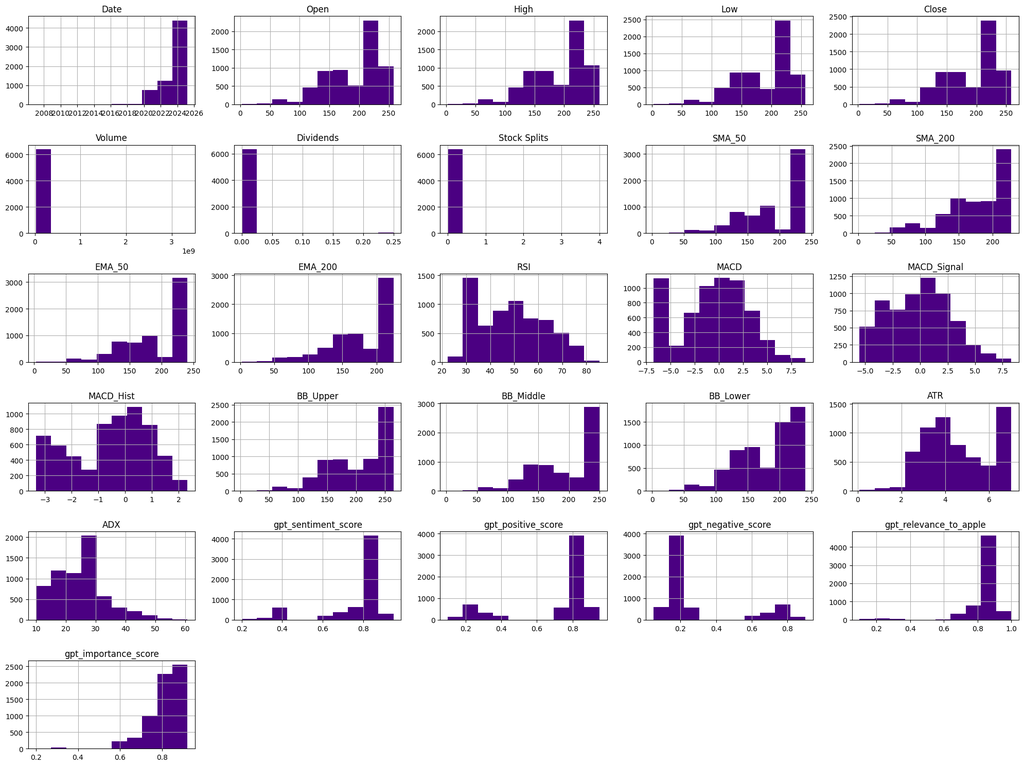

```python
df.hist(figsize=(20,15), bins=10, color='indigo')
plt.tight_layout()
plt.show()
```

```
array([[<Axes: title={'center': 'gpt_sentiment_score'}>,
        <Axes: title={'center': 'gpt_positive_score'}>,
        <Axes: title={'center': 'gpt_negative_score'}>],
       [<Axes: title={'center': 'gpt_importance_score'}>,
        <Axes: title={'center': 'gpt_relevance_to_apple'}>,
        <Axes: title={'center': 'RSI'}>],
       [<Axes: title={'center': 'MACD'}>,
        <Axes: title={'center': 'MACD_Hist'}>,
        <Axes: title={'center': 'Volume'}>],
       [<Axes: title={'center': 'Close'}>, <Axes: >, <Axes: >]],
      dtype=object)
```

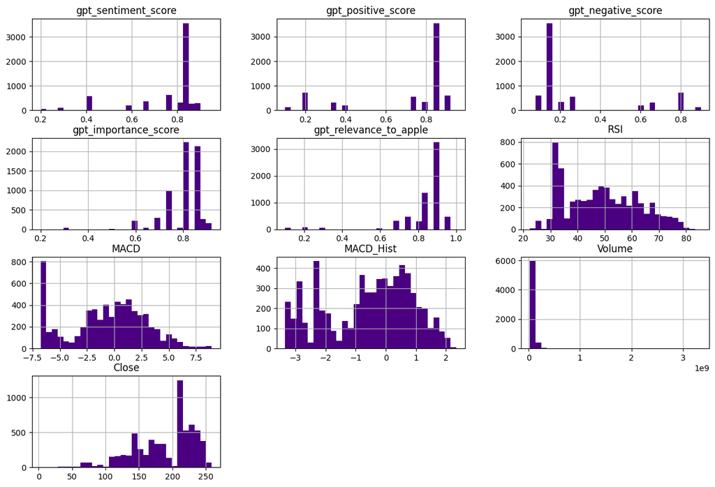

```python
df[[
    "gpt_sentiment_score", "gpt_positive_score", "gpt_negative_score",
    "gpt_importance_score", "gpt_relevance_to_apple",
    "RSI", "MACD", "MACD_Hist", "Volume", "Close"
]].hist(figsize=(15, 10), bins=30, color='indigo')
```

```python
df.describe()
```

|  | Open | High | Low | Close | Volume | Dividends | Stock Splits | SMA_50 | SMA_200 | EMA_50 | ... | BB_Upper | BB_Middle | BB_Lower | ATR | ADX | gpt_sentiment_score | gpt_positive_score | gpt_negative_score | gpt_relevance_to_apple | gpt_importance_score |
| --- | --- | --- | --- | --- | --- | --- | --- | --- | --- | --- | --- | --- | --- | --- | --- | --- | --- | --- | --- | --- | --- |
| count | 6415.000000 | 6415.000000 | 6415.000000 | 6415.000000 | 6.415000e+03 | 6415.000000 | 6415.000000 | 6415.000000 | 6415.000000 | 6415.000000 | ... | 6415.000000 | 6415.000000 | 6415.000000 | 6415.000000 | 6415.000000 | 6415.000000 | 6415.000000 | 6415.000000 | 6415.000000 | 6415.000000 |
| mean | 189.341335 | 191.425654 | 187.196573 | 189.307935 | 7.301673e+07 | 0.002464 | 0.001871 | 191.548327 | 179.457543 | 190.989399 | ... | 204.922154 | 192.509189 | 180.096223 | 4.557334 | 24.946596 | 0.764868 | 0.716633 | 0.283367 | 0.843595 | 0.801894 |
| std | 45.133448 | 45.467503 | 44.586510 | 44.955826 | 6.030155e+07 | 0.024220 | 0.086488 | 48.175300 | 46.602038 | 47.808564 | ... | 52.131317 | 48.056652 | 44.652937 | 1.470495 | 8.408056 | 0.160686 | 0.246556 | 0.246556 | 0.132648 | 0.074741 |
| min | 2.601592 | 2.798103 | 2.562470 | 2.785764 | 2.323470e+07 | 0.000000 | 0.000000 | 2.575001 | 2.139975 | 2.536140 | ... | 2.751056 | 2.575109 | 2.399162 | 0.088980 | 9.891966 | 0.200000 | 0.100000 | 0.050000 | 0.100000 | 0.200000 |
| 25% | 154.545811 | 155.747738 | 152.036458 | 153.912216 | 4.801330e+07 | 0.000000 | 0.000000 | 154.175806 | 150.785042 | 152.522717 | ... | 164.534158 | 154.007906 | 143.420054 | 3.319865 | 18.607162 | 0.750000 | 0.750000 | 0.150000 | 0.850000 | 0.780000 |
| 50% | 211.250000 | 213.949997 | 209.580002 | 212.690002 | 5.937500e+07 | 0.000000 | 0.000000 | 212.253434 | 188.762177 | 211.931633 | ... | 230.353916 | 222.719859 | 203.571852 | 4.275861 | 25.592157 | 0.850000 | 0.850000 | 0.150000 | 0.900000 | 0.820000 |
| 75% | 223.809998 | 225.839996 | 221.994983 | 223.983734 | 8.222550e+07 | 0.000000 | 0.000000 | 233.455149 | 223.910876 | 232.604933 | ... | 253.157259 | 232.457500 | 218.551446 | 6.078266 | 28.569301 | 0.850000 | 0.850000 | 0.250000 | 0.900000 | 0.850000 |
| max | 257.906429 | 259.814335 | 257.347047 | 258.735504 | 3.349298e+09 | 0.250000 | 4.000000 | 240.485810 | 227.948397 | 240.882988 | ... | 264.405561 | 249.710449 | 240.302475 | 7.011365 | 60.755189 | 0.950000 | 0.950000 | 0.900000 | 1.000000 | 0.920000 |

8 rows × 25 columns

```python
df_missing = (df.isnull().mean() * 100).round(2)
print(df_missing)
```

```
Title                      0.0
Date                       0.0
Link                       0.0
Source                     0.0
Open                       0.0
High                       0.0
Low                        0.0
Close                      0.0
Volume                     0.0
Dividends                  0.0
Stock Splits               0.0
SMA_50                     0.0
SMA_200                    0.0
EMA_50                     0.0
EMA_200                    0.0
RSI                        0.0
MACD                       0.0
MACD_Signal                0.0
MACD_Hist                  0.0
BB_Upper                   0.0
BB_Middle                  0.0
BB_Lower                   0.0
ATR                        0.0
ADX                        0.0
gpt_summary                0.0
gpt_sentiment_direction    0.0
gpt_sentiment_score        0.0
gpt_positive_score         0.0
gpt_negative_score         0.0
gpt_event_type             0.0
gpt_relevance_to_apple     0.0
gpt_importance_score       0.0
dtype: float64
```

```python
print("Duplicates:", df.duplicated().sum())
duplicates = df[df.duplicated()]
print(f"Total Duplicates: {len(duplicates)}")
duplicates
```

```
Duplicates: 2
Total Duplicates: 2
```

|  | Title | Date | Link | Source | Open | High | Low | Close | Volume | Dividends | ... | ATR | ADX | gpt_summary | gpt_sentiment_direction | gpt_sentiment_score | gpt_positive_score | gpt_negative_score | gpt_event_type | gpt_relevance_to_apple | gpt_importance_score |
| --- | --- | --- | --- | --- | --- | --- | --- | --- | --- | --- | --- | --- | --- | --- | --- | --- | --- | --- | --- | --- | --- |
| 414 | Introducing the next generation of Mac - Apple... | 2020-11-10 08:00:00+00:00 | https://news.google.com/rss/articles/CBMiiAFBV... | Google RSS | 112.867044 | 114.859671 | 111.480009 | 113.27729 | 138023400 | 0.0 | ... | 4.084511 | 15.207292 | Apple has announced the launch of the next gen... | Positive | 0.85 | 0.85 | 0.15 | Product | 0.9 | 0.85 |
| 418 | Introducing the next generation of Mac - Apple... | 2020-11-10 08:00:00+00:00 | https://news.google.com/rss/articles/CBMiiAFBV... | Google RSS | 112.867044 | 114.859671 | 111.480009 | 113.27729 | 138023400 | 0.0 | ... | 4.084511 | 15.207292 | Apple has announced the launch of the next gen... | Positive | 0.85 | 0.85 | 0.15 | Product | 0.9 | 0.85 |

2 rows × 32 columns

```python
df=df.drop_duplicates()
```

```python
print("Duplicates:", df.duplicated().sum())
duplicates = df[df.duplicated()]
print(f"Total Duplicates: {len(duplicates)}")
duplicates
```

```
Duplicates: 0
Total Duplicates: 0
```

|  | Title | Date | Link | Source | Open | High | Low | Close | Volume | Dividends | ... | ATR | ADX | gpt_summary | gpt_sentiment_direction | gpt_sentiment_score | gpt_positive_score | gpt_negative_score | gpt_event_type | gpt_relevance_to_apple | gpt_importance_score |
| --- | --- | --- | --- | --- | --- | --- | --- | --- | --- | --- | --- | --- | --- | --- | --- | --- | --- | --- | --- | --- | --- |

0 rows × 32 columns

```python
df["target"] = df["Close"].shift(-1) - df["Close"]
df = df.dropna(subset=["target"])
print(df.columns)
```

```
Index(['Title', 'Date', 'Link', 'Source', 'Open', 'High', 'Low', 'Close',
       'Volume', 'Dividends', 'Stock Splits', 'SMA_50', 'SMA_200', 'EMA_50',
       'EMA_200', 'RSI', 'MACD', 'MACD_Signal', 'MACD_Hist', 'BB_Upper',
       'BB_Middle', 'BB_Lower', 'ATR', 'ADX', 'gpt_summary',
       'gpt_sentiment_direction', 'gpt_sentiment_score', 'gpt_positive_score',
       'gpt_negative_score', 'gpt_event_type', 'gpt_relevance_to_apple',
       'gpt_importance_score', 'target'],
      dtype='object')
```

```python
features=[
    "RSI", "MACD", "MACD_Signal", "MACD_Hist",
    "BB_Upper", "BB_Middle", "BB_Lower",
    "ATR", "ADX", "Volume",
    "gpt_sentiment_score", "gpt_positive_score", "gpt_negative_score",
    "gpt_importance_score", "gpt_relevance_to_apple",
]
```

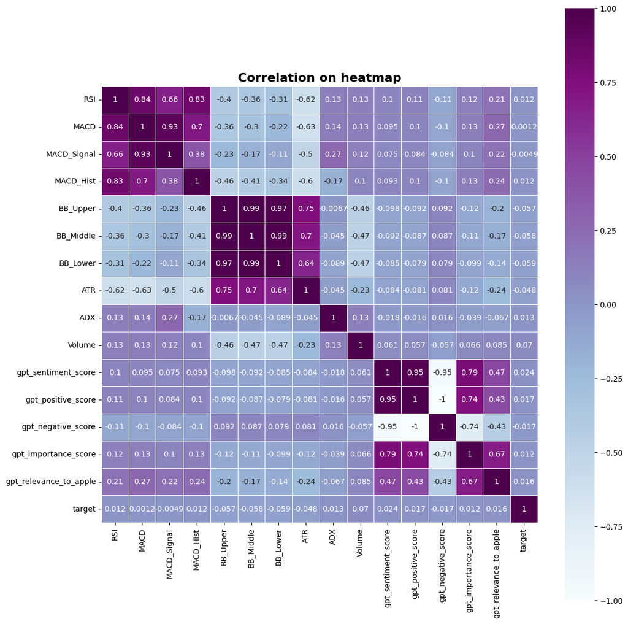

```python
feature_selections= features + ["target"]
cor1=df[feature_selections].corr()
plt.figure(figsize=(12,12))
sb.heatmap(cor1, annot=True, cmap='BuPu', linewidths=0.5, square=True)
plt.title('Correlation on heatmap', fontsize=16, fontweight='bold')
plt.tight_layout()
plt.show()
```

# Features of Importance

```
X_train:  (6412, 15)
Y_train:  (6412,)

 Scores of Importances
 [0.07453338 0.06038833 0.06413385 0.07413538 0.06048859 0.05056873
 0.05415478 0.08993331 0.09895428 0.07709433 0.0435145  0.03909295
 0.03375041 0.13075121 0.04850598]
```

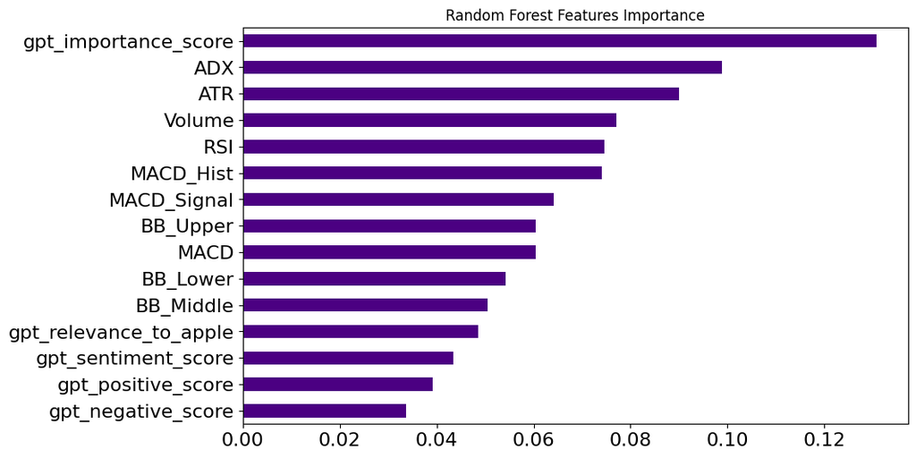

```python
x= df[features]
y= df['target']
x_train, x_test, y_train, y_test= train_test_split(x,y,test_size=0.3, random_state=42)
print("X_train: ", x.shape)
print("Y_train: ", y.shape)

rf_imp= RandomForestRegressor(n_estimators=50, random_state=42)
rf_imp.fit(x_train, y_train)

importances = rf_imp.feature_importances_
importances_df = pd.Series(importances, index=features).sort_values()
importances_df.plot (kind='barh', color='indigo', title='Random Forest Features Importance', fontsize='16', figsize=(10,6))
print("\n Scores of Importances\n", importances)
```

We applied a Random Forest Regressor to assess the relative importance of both technical indicators and GPT-enriched news features in predicting next-day Apple stock price movement.

Contrary to initial assumptions, the feature *gpt_importance_score* emerged as the most influential predictor, even surpassing traditional indicators like *Volume, RSI, and MACD*.

This finding highlights the growing value of semantic and contextual understanding from financial news. Other significant contributors included ADX, ATR, and MACD_Hist, indicating that combining sentiment enrichment with volatility and momentum indicators offers a more holistic model perspective.